# Lab 1: Séries de TV

André Victor de Andrade Lopes

23 de abril de 2018

# Preparando os Dados

A primeira parte foi construir um data frame com os dados que foram obtidos e estão disponíveis em csv (data/series_from_imdb.csv).  
Em seguida foram extraidos os nomes das séries e quantidade de episódios cujos dados estão disponíveis.

```r
dados = read_csv(here("data/series_from_imdb.csv"),
                    progress = FALSE,
                    col_types = cols(series_name = col_character(),
                                     episode = col_character(),
                                     url = col_character(),
                                     season = col_character()))

series = unique(subset(dados, select=c("series_name")))
series_ = dados %>%
            group_by(series_name) %>%
            summarise(n = n())
```

# Shondaland

[figure not shown]

Shondaland é uma produtora americana que é responsável pelas séries Grey’s Anatomy, Scandal, How To Get Away With Murder e outras. As três séries são exibidas no canal aberto ABC no mesmo dia da semana (Quinta-Feira) a noite. A análise será feita levando em consideração a avalição de duas das principais séries da Shondaland: **Scandal** e **How To Get Away With Murder**.

## How To Get Away With Murder

[figure not shown]

### Onde estão os melhores episódios? Inicio meio ou fim da temporada?

Primeiro vamos analisar How To Get Away With Murder. O gráfico de linhas abaixo nos ajuda a compreender como a avaliação dos episódios série se comporta de forma parecida nas três temporadas.

[figure not shown]

```r
htgawm = shondaland %>%
    filter(series_name %in% c("How to Get Away with Murder"))

ggplot(data=htgawm,
       aes(x=season_ep,
           y=user_rating,
           color=series_name)) +
    geom_line() +
    geom_point() +
    geom_vline(xintercept = 9,
               linetype="dotted",
                color = "#a1a1a1",
               size=0.5) +
    facet_wrap(~ season) +
    guides(color=FALSE)  +
    labs(x = "Episódio",
         y = "Avaliação no IMDB") +
    ggtitle("Avaliação do episódio por temporada")
```

Na primeira parte da série (que é exibida entre setembro e dezembro) os episódios apresentam uma média de avalição que varia entre 8 e 9, até chegar no mid-season (episódio 9) que é o episódio com a maior média na temporada.  
O Mid-season é o episódio que divide o plot da história. Nele, acontecem algumas revelações sobre os mistérios que foram apresentados na série até o momento, também é onde é apresentado o gancho para a segunda parte da temporada. Depois disso, os episódios da temporada voltam a ter uma média mais baixa que segue um progressão positiva tendo o seu segundo pico na season finale (episódio do final da temporada).  
Embora sua tradução seja “Meio de temporada”, o “mid-season” não é necessariamente o episódio que numericamente divide a temporada.  
Considerando: Primeiro episódio, Meio e final da temporada, temos:  
#1: Meio (9.4, 9.6, 9.6)  
#2: final (9.4, 9.2, 9.1)  
Assim, para How to Get Away with Murder os melhores episódios são os **mid-season**.

## Scandal

[figure not shown]

### Onde estão os melhores episódios? Inicio meio ou fim da temporada?

Já em Scandal, temos um comportamento diferente:

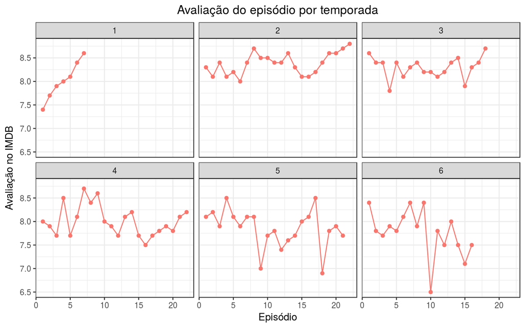

```r
scandal = shondaland %>% filter(series_name %in% c("Scandal"))
ggplot(data=scandal, aes(x=season_ep,
                         y=user_rating,
                         group=series_name,
                         color=series_name)) +
    geom_line()+
    geom_point() +
    facet_wrap(~ season) +
    guides(color=FALSE)  +
    labs(x = "Episódio",
         y = "Avaliação no IMDB") +
    ggtitle("Avaliação do episódio por temporada")
```

## Qual das duas séries tem episódios de qualidade mais irregular segundo o IMDB?

Após analisar os gráficos acima, podemos decidir que **Scandal** é a série com maior irregularidade nas avaliações dos episódios, principalmente nas duas ultimas temporadas. Podemos mostrar isso com a ajuda de valores estatísticos como a variancia e desvião padrão, esses valores nos ajudam a compreender quão grande é a diferença dos valores reais relação a média esperada.

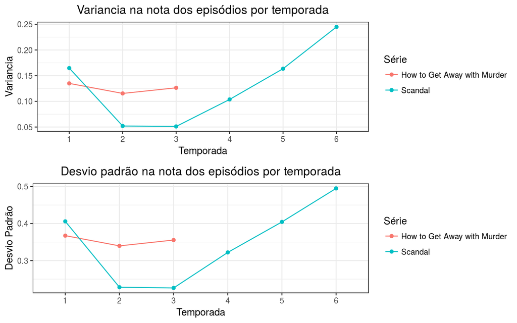

```r
shondaland_variance = ggplot(data=basic_statistic,
                             aes(x=season,
                                 y=variance,
                                 group=series_name,
                                 color=series_name)) +
    geom_line() +
    geom_point()  +
    labs(x = "Temporada",
         y = "Variancia",
         color = "Série") +
    ggtitle("Variancia na nota dos episódios por temporada")

shondaland_sd = ggplot(data=basic_statistic,
                             aes(x=season,
                                 y=sd,
                                 group=series_name,
                                 color=series_name)) +
    geom_line() +
    geom_point() +
    labs(x = "Temporada",
         y = "Desvio Padrão",
         color = "Série") +
    ggtitle("Desvio padrão na nota dos episódios por temporada")
grid.arrange(shondaland_variance, shondaland_sd)
```

## Qual série é mais bem avaliada?

Para isso vamos dar uma olhada na distribuição das notas das séries com a ajuda de um box-plot:

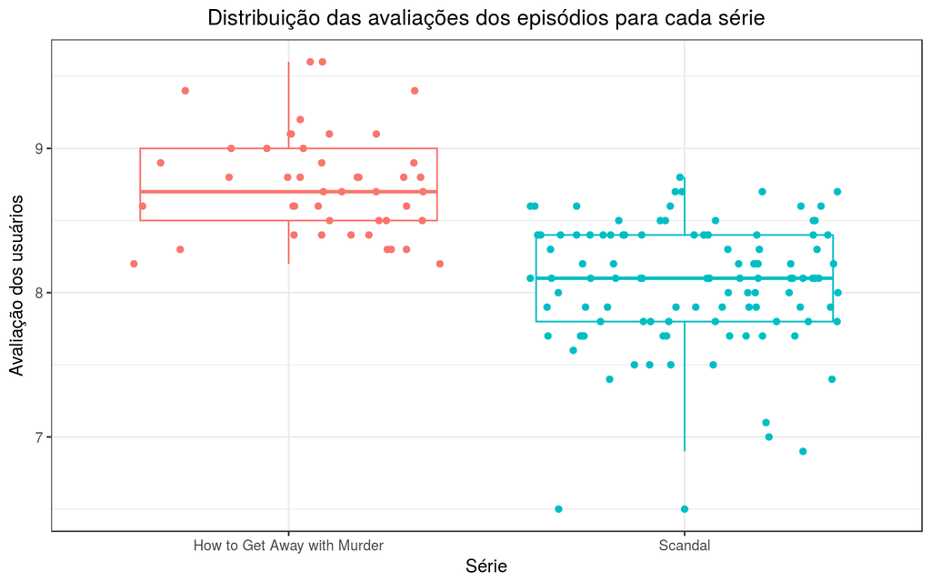

```r
boxplot_shondaland <- ggplot(shondaland,
                             aes(x = series_name,
                                 y = user_rating,
                                 color= series_name)) +
    geom_boxplot() +
    geom_jitter(position = position_jitter(w = 0.4,
                                           h = 0)) +
    guides(color=FALSE)  +
    labs(x = "Série",
         y = "Avaliação dos usuários") +
    ggtitle("Distribuição das avaliações dos episódios para cada série")
boxplot_shondaland
```

Com a ajuda do boxplot podemos ver que as notas de How To Get Away With Murder são significativamente maiores que as de Scandal. Enquanto 75% das notas de How To Get Away With Murder estão acima de 8.5, 75% das notas de Scandal estão abaixo desse valor. Além disso, embora a média de ambas as séries estejam diminuindo, a média de Scandal, mesmo eu seu pico, é menor do que a menor média atingida por How To Get Away With Murder.  
*Side note: Curiosamente, ambas as séries tem a melhor média na segunda temporada*

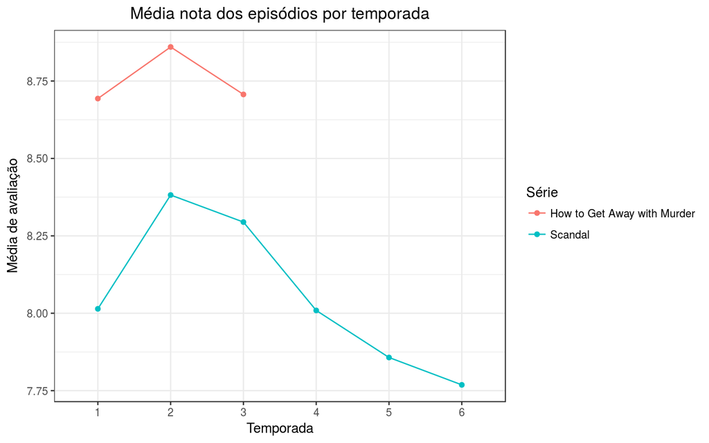

```r
shodaland_mean = ggplot(data=basic_statistic,
                             aes(x=season,
                                 y=average,
                                 group=series_name,
                                 color=series_name)) +
    geom_line() +
    geom_point() +
    labs(x = "Temporada",
         y = "Média de avaliação",
         color = "Série") +
    ggtitle("Média nota dos episódios por temporada")
shodaland_mean
```

Porém essa diferença não é muito grande, nem quer dizer que Scandal seja mal avaliada. Aliás, a média de avaliação de Scandal continua perto de 8 (Na sexta temporada, a média chegou próxima a 7.75).

## E os episódios sem graça?

Alguns episódios, como diriam o dito popular *“Nem fede, nem cheira”* , ou seja, não são nem bons, nem ruins. São medianos, “okay”“, preechem o tempo sem oferecer nenhum sentimento muito forte (de amor ou odio). Para a analise, esses episódios são aqueles que foram classificados entre 4 e 7 pelos usuários.  
Para isso, foi criada uma variável”nah" que é a o valor de r4, r5, r6, r7 *(onde, cada rx significa: proporção de usuários que avaliaram o episódio com nota x)* multiplicado por 100 (Para montarmos o gráfico considerando a porcentagem).

```r
shonda_nah <- shondaland %>%
                mutate(nah = r4*100 + r5*100 + r6*100 + r7 *100)
```

### How To Get Away With Murder

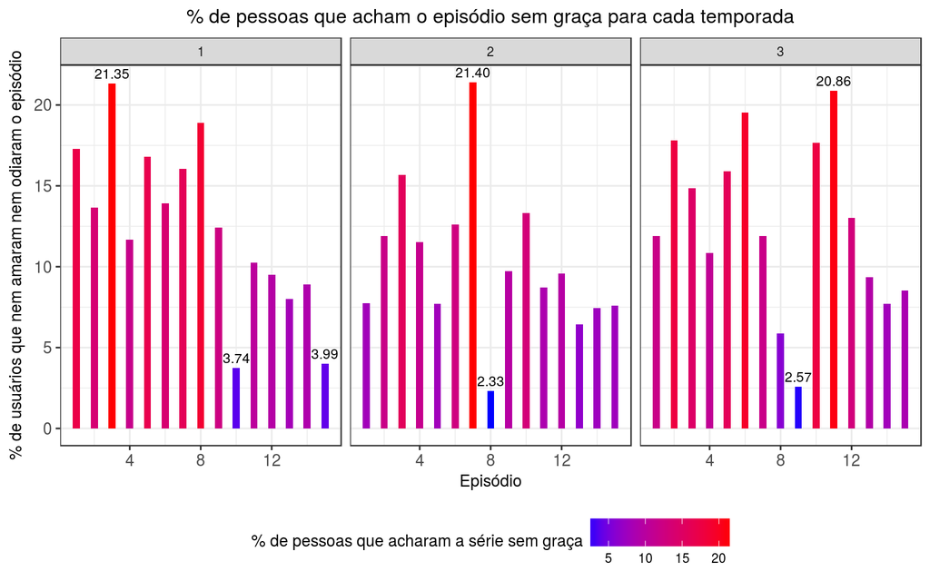

```r
htgawm_nah <- shonda_nah %>% filter(series_name %in% c("How to Get Away with Murder"))

ggplot(htgawm_nah,
       aes(season_ep,
           nah,
           fill=nah)) +
        geom_bar(width=0.4,
                 stat="identity") +
        geom_text(data=subset(htgawm_nah,
                              nah > 20| nah <5),
                  aes(label=sprintf("%0.2f",
                                    round(nah, digits = 2))),
                  hjust=0.5,
                  vjust=-0.5,
                  size= 3) +
    theme(text = element_text(size = 10)) +
    theme(axis.text = element_text(size = 10)) +
    theme(legend.position="bottom") +
    scale_fill_gradient(low="blue", high="red") +
    facet_grid( ~ season) +
    labs(x = "Episódio",
         y = "% de usuários que nem amaram nem odiaram o episódio",
         fill = "% de pessoas que acharam a série sem graça") +
    ggtitle("% de pessoas que acham o episódio sem graça para cada temporada")
```

Em How To Get Away With Murder, apenas um episódio de cada temporada é considerado sem graça por mais de 20% dos usuários. Nas duas primeiras temporadas, esse episódio ocorreu antes do meio da temporada.

### Scandal

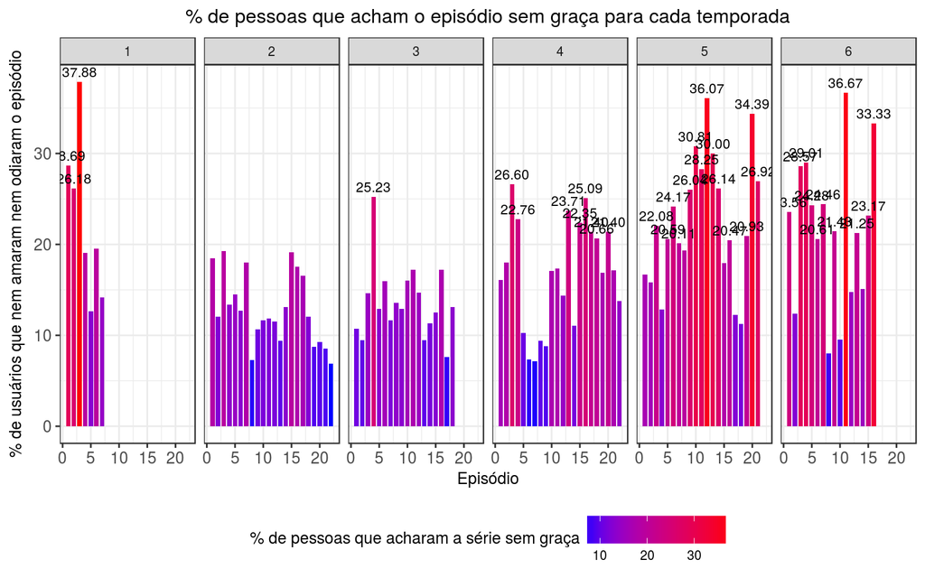

```r
scandal_nah <- shonda_nah %>% filter(series_name %in% c("Scandal"))

ggplot(scandal_nah, aes(season_ep,
                        nah,
                        fill = nah)) +
        geom_bar(width = 0.8,
                 stat = "identity",
                 position = position_dodge(.3)) +
        geom_text(data=subset(scandal_nah,
                              nah > 20),
                  aes(label = sprintf("%0.2f",
                                    round(nah, digits = 2))),
                  hjust=0.5,
                  vjust=-0.5,
                  size= 3) +
    theme(text = element_text(size = 10)) +
    theme(axis.text = element_text(size = 10)) +
    scale_fill_gradient(low="blue", high="red") +
    theme(legend.position="bottom") +
    facet_grid( ~ season) +
    labs(x = "Episódio",
         y = "% de usuários que nem amaram nem odiaram o episódio",
         fill = "% de pessoas que acharam a série sem graça") +
    ggtitle("% de pessoas que acham o episódio sem graça para cada temporada")
```

A segunda temporada de Scandal não tem nenhum episódio onde mais de 20% dos usuários tenham classificado o episódio como sem graça. Já na quinta e sexta temporada, existe mais de 10 episódios sem graça. Mais que isso, na primeira, quinta e sexta temporada, existem episódios onde mais de 30% dos usuários acham o episódio sem graça. Assim, **Scandal** é, entre as duas séries, a série com mais episódios sem graça.